# chapter 3

Yu Ren

2022-11-16

prepare some packages

```r
library(tidyverse)
library(dplyr)
```

1. read the joined student alcohol consumption data

```r
alc <- read_csv("alc.csv")
```

1.2 Print out the names of the variables in the data and describe the data set briefly

```r
glimpse(alc)
```

```
## Rows: 370
## Columns: 35
## $ school     <chr> "GP", "GP", "GP", "GP", "GP", "GP", "GP", "GP", "GP", "GP",…
## $ sex        <chr> "F", "F", "F", "F", "F", "M", "M", "F", "M", "M", "F", "F",…
## $ age        <dbl> 18, 17, 15, 15, 16, 16, 16, 17, 15, 15, 15, 15, 15, 15, 15,…
## $ address    <chr> "U", "U", "U", "U", "U", "U", "U", "U", "U", "U", "U", "U",…
## $ famsize    <chr> "GT3", "GT3", "LE3", "GT3", "GT3", "LE3", "LE3", "GT3", "LE…
## $ Pstatus    <chr> "A", "T", "T", "T", "T", "T", "T", "A", "A", "T", "T", "T",…
## $ Medu       <dbl> 4, 1, 1, 4, 3, 4, 2, 4, 3, 3, 4, 2, 4, 4, 2, 4, 4, 3, 3, 4,…
## $ Fedu       <dbl> 4, 1, 1, 2, 3, 3, 2, 4, 2, 4, 4, 1, 4, 3, 2, 4, 4, 3, 2, 3,…
## $ Mjob       <chr> "at_home", "at_home", "at_home", "health", "other", "servic…
## $ Fjob       <chr> "teacher", "other", "other", "services", "other", "other", …
## $ reason     <chr> "course", "course", "other", "home", "home", "reputation", …
## $ guardian   <chr> "mother", "father", "mother", "mother", "father", "mother",…
## $ traveltime <dbl> 2, 1, 1, 1, 1, 1, 1, 2, 1, 1, 1, 3, 1, 2, 1, 1, 1, 3, 1, 1,…
```

[output cut: 22 more lines]

The dataset has 370 observations and 35 variables. I will explain some meanings of variables: famsize-family size; Pstatus - parent’s cohabitation status; Medu - mother’s education; Fedu - father’s education; Mjob - mother’s job; Fjob - father’s job; reason - reason to choose this school; guardian - student’s guardian; schoolsup - extra educational support; famsup - family educational support; activities - extra-curricular activities; nursery - attended nursery school; higher - wants to take higher education; internet - Internet access at home; romantic - with a romantic relationship; famrel - quality of family relationships; freetime - free time after school; goout - going out with friends; Dalc - workday alcohol consumption; Walc - weekend alcohol consumption; health - current health status; absences - number of school absences; G1 - first period grade; G2 - second period grade; G3 - final grade.

2. Choose 4 variables and present personal hypothesis The four variables I have chosen are goout - going out with friends, freetime - free time after school，famrel - quality of family relationships and absences - number of school absences. I suspect that these four variables would be related to student drinking; having free time after school and going out with friends multiple times may increase the frequency of drinking, the quality of family relationships may also influence drinking status, and there may be a relationship between absence from class and drinking.

3.Explore the distributions of variables and their relationships with alcohol consumption

```r
alc %>% group_by(freetime) %>% summarise(count = n())
```

```
## # A tibble: 5 × 2
##   freetime count
##      <dbl> <int>
## 1        1    17
## 2        2    60
## 3        3   152
## 4        4   105
## 5        5    36
```

```r
alc %>% group_by(goout) %>% summarise(count = n())
```

```
## # A tibble: 5 × 2
##   goout count
##   <dbl> <int>
## 1     1    22
## 2     2    97
## 3     3   120
## 4     4    78
## 5     5    53
```

```r
alc %>% group_by(famrel) %>% summarise(count = n())
```

```
## # A tibble: 5 × 2
##   famrel count
##    <dbl> <int>
## 1      1     8
## 2      2    18
## 3      3    64
## 4      4   180
## 5      5   100
```

```r
alc %>% group_by(absences) %>% summarise(count = n())
```

```
## # A tibble: 26 × 2
##    absences count
##       <dbl> <int>
##  1        0    63
##  2        1    50
##  3        2    56
##  4        3    38
##  5        4    35
##  6        5    22
##  7        6    21
##  8        7    12
##  9        8    20
## 10        9    11
## # … with 16 more rows
```

The distribution of the freetime and goout variables is more in the middle, with the family relationship variables mostly distributed between 3 and 5, indicating that the majority of students have good family relationships; classroom absences, the majority of students are absent 5 times or less.

3.1 explore alcohol high use and freetime

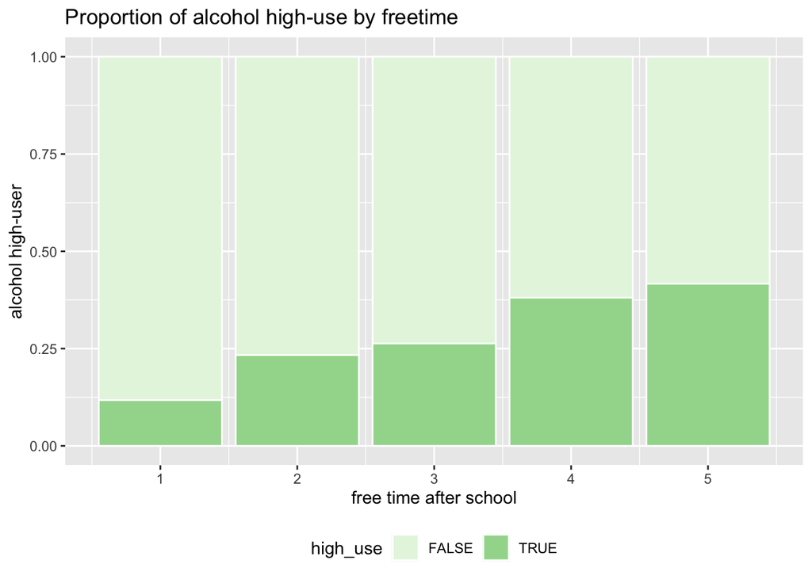

```r
p1 <- alc %>%
  ggplot(aes(x = freetime, fill = high_use)) +
  geom_bar(position = "fill", color ="white") +
  labs(x = "free time after school", y = "alcohol high-user",
       title = "Proportion of alcohol high-use by freetime")+
  theme(legend.position = "bottom")+
  scale_fill_discrete(labels = c("FALSE" = "Non-high-user",
                                 "TRUE" = "high-user"))+
  scale_fill_brewer(palette = "")
p1
```

According to the proportions shown in the bar chart, the proportion of alcohol use increases gradually as leisure time after school increases.

3.2 explore alcohol high use and goout

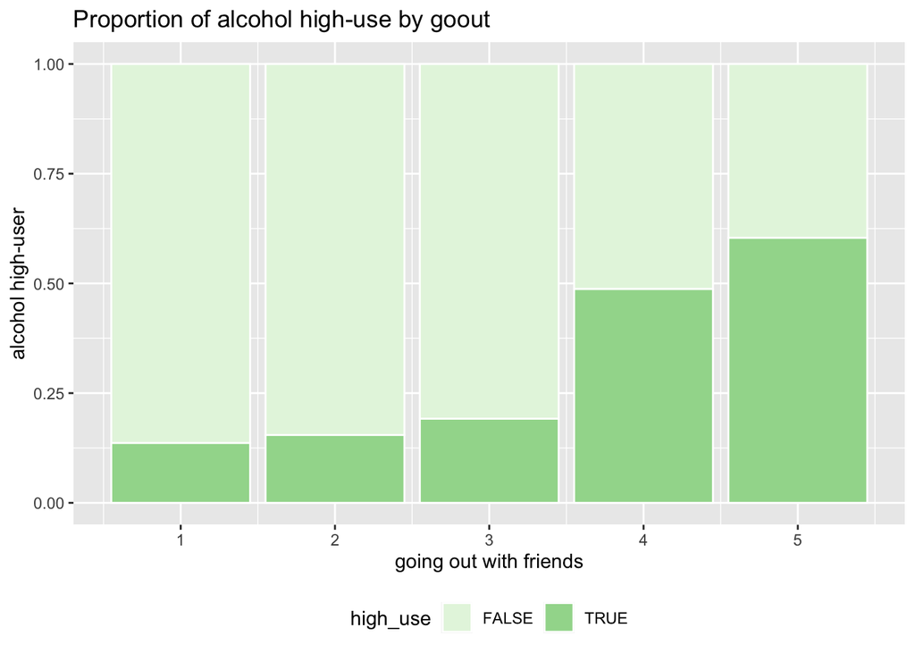

```r
p2 <- alc %>%
  ggplot(aes(x = goout, fill = high_use)) +
  geom_bar(position = "fill", color ="white") +
  labs(x = "going out with friends", y = "alcohol high-user",
       title = "Proportion of alcohol high-use by goout")+
  theme(legend.position = "bottom")+
  scale_fill_discrete(labels = c("FALSE" = "Non-high-user",
                                 "TRUE" = "high-user"))+
  scale_fill_brewer(palette = "")
p2
```

According to the bar scale, the proportion of alcohol consumption increases as the number of outings with friends increases, particularly at level 4 of the outing degree, where the proportion increases substantially.

3.3explore alcohol high use and famrel

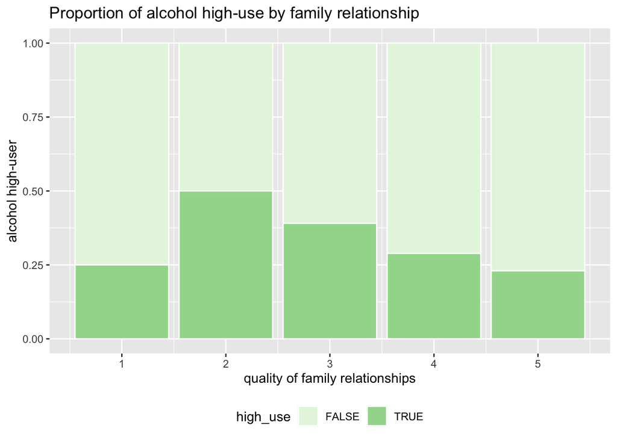

```r
p3 <- alc %>%
  ggplot(aes(x = famrel, fill = high_use)) +
  geom_bar(position = "fill", color ="white") +
  labs(x = "quality of family relationships", y = "alcohol high-user",
       title = "Proportion of alcohol high-use by family relationship")+
  theme(legend.position = "bottom")+
  scale_fill_discrete(labels = c("FALSE" = "Non-high-user",
                                 "TRUE" = "high-user"))+
  scale_fill_brewer(palette = "")
p3
```

“famrel - quality of family relationships (numeric: from 1 - very bad to 5 - excellent)” Family relationships start at level 3, with better family relationships being accompanied by a lower proportion of alcohol consumption. The highest proportion of alcohol consumption is found when family relationships are poor.

3.4 explore alcohol high use and absences

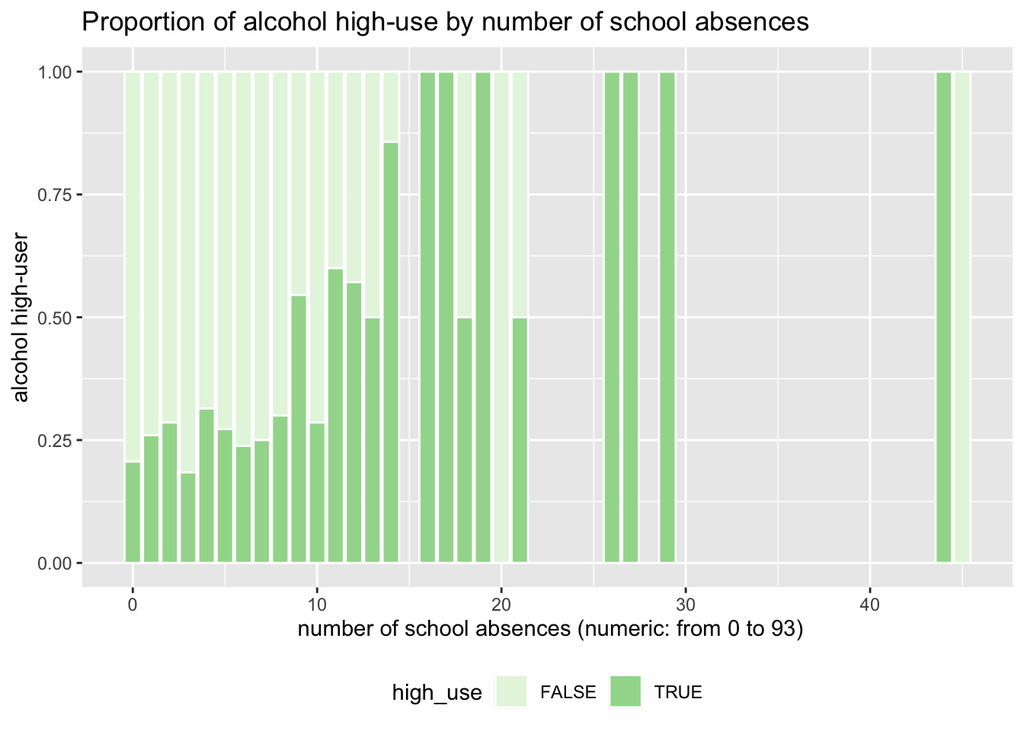

```r
p4 <- alc %>%
  ggplot(aes(x = absences, fill = high_use)) +
  geom_bar(position = "fill", color ="white") +
  labs(x = " number of school absences (numeric: from 0 to 93)", y = "alcohol high-user",
       title = "Proportion of alcohol high-use by number of school absences")+
  theme(legend.position = "bottom")+
  scale_fill_discrete(labels = c("FALSE" = "Non-high-user",
                                 "TRUE" = "high-user"))+
  scale_fill_brewer(palette = "")
p4
```

As the number of absences from school increases, the proportion of alcohol consumption increases with it. The bars show much the same results as I expected, the only differences being family relationships and alcohol consumption rates, with the worst families not having the highest rates of alcohol consumption and the second worst families having the highest rates of alcohol consumption.

4.logistic regression model 4.1

```r
m1 <- glm(high_use ~ freetime + goout + famrel + absences, data = alc, family = "binomial")

summary(m1)
```

```
##
## Call:
## glm(formula = high_use ~ freetime + goout + famrel + absences,
##     family = "binomial", data = alc)
##
## Deviance Residuals:
##     Min       1Q   Median       3Q      Max
## -1.8393  -0.7676  -0.5200   0.9080   2.3909
##
## Coefficients:
##             Estimate Std. Error z value Pr(>|z|)
## (Intercept)  -2.7391     0.6975  -3.927  8.6e-05 ***
## freetime      0.2283     0.1393   1.639 0.101292
## goout         0.7103     0.1252   5.673  1.4e-08 ***
## famrel       -0.4019     0.1387  -2.898 0.003754 **
## absences      0.0761     0.0220   3.459 0.000543 ***
## ---
## Signif. codes:  0 '***' 0.001 '**' 0.01 '*' 0.05 '.' 0.1 ' ' 1
##
## (Dispersion parameter for binomial family taken to be 1)
##
##     Null deviance: 452.04  on 369  degrees of freedom
## Residual deviance: 380.08  on 365  degrees of freedom
## AIC: 390.08
##
## Number of Fisher Scoring iterations: 4
```

There is a highly significant relationship between the proportion of increased drinking and family relationships, the frequency of going out with friends and absence from class, but a non-significant p-value between this and free time.

4.2 From coefficients to odds ratios

```r
m1 <- glm(high_use ~ freetime + goout + famrel + absences, data = alc, family = "binomial")

# compute odds ratios (OR)
OR <- coef(m1) %>% exp
OR
```

```
## (Intercept)    freetime       goout      famrel    absences
##  0.06462506  1.25649062  2.03450512  0.66907685  1.07907060
```

```r
# compute confidence intervals (CI)
confint(m1)
```

```
##                   2.5 %     97.5 %
## (Intercept) -4.14545349 -1.4024140
## freetime    -0.04305995  0.5046433
## goout        0.47111595  0.9630772
## famrel      -0.67730666 -0.1316918
## absences     0.03387575  0.1213892
```

```r
CI <- exp(confint(m1))
CI
```

```
##                  2.5 %    97.5 %
## (Intercept) 0.01583625 0.2460024
## freetime    0.95785396 1.6563946
## goout       1.60178070 2.6197457
## famrel      0.50798332 0.8766111
## absences    1.03445607 1.1290642
```

```r
# print out the odds ratios with their confidence intervals
cbind(OR, CI)
```

```
##                     OR      2.5 %    97.5 %
## (Intercept) 0.06462506 0.01583625 0.2460024
## freetime    1.25649062 0.95785396 1.6563946
## goout       2.03450512 1.60178070 2.6197457
## famrel      0.66907685 0.50798332 0.8766111
## absences    1.07907060 1.03445607 1.1290642
```

5. Explore the predictive power of the model 5.1 Binary predictions（1）

```r
prob <- predict(m1, type = "response")
library(dplyr)

alc <- mutate(alc, probability = prob)
alc <- mutate(alc, prediction = probability > 0.5)

table(high_use = alc$high_use, prediction = alc$prediction)
```

```
##         prediction
## high_use FALSE TRUE
##    FALSE   239   20
##    TRUE     67   44
```

Of the 370 participants, there are 259 non-alcoholics, of which the model correctly predicted 239 (92.28%); of the 111 alcoholics, the model successfully predicted 44 (39.64%).

5.2 Binary predictions (2)

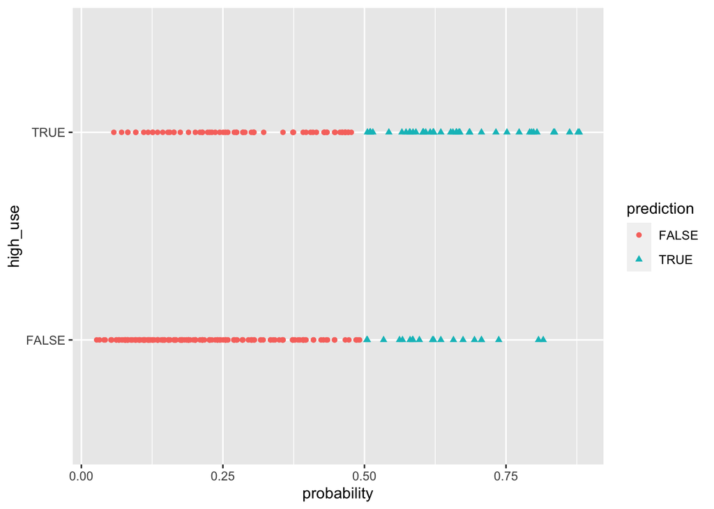

```r
library(dplyr); library(ggplot2)

# initialize a plot of 'high_use' versus 'probabilities' in 'alc'
g <- ggplot(alc, aes(x = probability, y = high_use))

# define the geom as points and draw the plot
g+aes(color = prediction, shape = prediction) + geom_point()
```

```r
# tabulate the target variable versus the predictions
table(high_use = alc$high_use, prediction = alc$prediction)
```

```
##         prediction
## high_use FALSE TRUE
##    FALSE   239   20
##    TRUE     67   44
```

6.Bonus

```r
# define a loss function (mean prediction error)
loss_func <- function(class, prob) {
  n_wrong <- abs(class - prob) > 0.5
  mean(n_wrong)
}
```

```r
training.error.full <- loss_func(alc$high_use, alc$probability)
training.error.full
```

```
## [1] 0.2351351
```

Prediction error rate of 23.51%.